# Tugas-Pertemuan-3

# Import Data

```r
library(readr)
data <- read.csv("D:\\Doc Helmi\\Semester 5\\MPDW\\mpdw\\pertemuan 3\\NewDelhi_Air_quality.csv")
data <- data[,c("AQI", "no2")]
str(data)
```

```
## 'data.frame':    72 obs. of  2 variables:
##  $ AQI: num  30.2 28.2 26.6 25 26 26 26 24 23 24 ...
##  $ no2: num  0.0469 0.0465 0.0469 0.0482 0.0489 ...
```

```r
head(data)
```

```
##    AQI        no2
## 1 30.2 0.04685717
## 2 28.2 0.04645554
## 3 26.6 0.04685717
## 4 25.0 0.04819594
## 5 26.0 0.04886533
## 6 26.0 0.05020411
```

# Pembagian Data

```r
#SPLIT DATA
train<-data[1:57,]
test<-data[58:72,]
```

```r
#data time series
train.ts<-ts(train)
test.ts<-ts(test)
data.ts<-ts(data)
```

# Model Koyck

```r
#MODEL KOYCK
model.koyck <- koyckDlm(x = train$no2, y = train$AQI)
summary(model.koyck)
```

```
##
## Call:
## "Y ~ (Intercept) + Y.1 + X.t"
##
## Residuals:
##      Min       1Q   Median       3Q      Max
## -2.22117 -0.48388 -0.04424  0.56575  2.23616
##
## Coefficients:
##             Estimate Std. Error t value Pr(>|t|)
## (Intercept)  2.46731    1.55225   1.590    0.118
## Y.1          0.85980    0.06108  14.076   <2e-16 ***
## X.t         27.86813   17.31971   1.609    0.114
## ---
## Signif. codes:  0 '***' 0.001 '**' 0.01 '*' 0.05 '.' 0.1 ' ' 1
##
## Residual standard error: 0.9049 on 53 degrees of freedom
## Multiple R-Squared: 0.8279,  Adjusted R-squared: 0.8215
## Wald test: 127.3 on 2 and 53 DF,  p-value: < 2.2e-16
##
## Diagnostic tests:
## NULL
##
##                             alpha     beta       phi
## Geometric coefficients:  17.59833 27.86813 0.8597988
```

```r
AIC(model.koyck)
```

```
## [1] 152.641
```

```r
BIC(model.koyck)
```

```
## [1] 160.7424
```

Dari hasil tersebut, didapat bahwa peubah $x_t$ memiliki nilai $P-Value>0.05$ dan $y_{t-1}$ memiliki nilai $P-Value<0.05$ . Hal ini menunjukkan bahwa peubah $x_t$ tidak berpengaruh signifikan sedangkan $y_{t-1}$ berpengaruh signifikan terhadap $y$. Adapun model keseluruhannya adalah sebagai berikut

$$\hat{Y_t}=2.46731+27.86813X_t+0.8598Y_{t-1}$$

```r
str(test)
```

```
## 'data.frame':    15 obs. of  2 variables:
##  $ AQI: num  23 22 21 20 19 19 20 21 21 21 ...
##  $ no2: num  0.0372 0.0274 0.0213 0.0176 0.0157 ...
```

### Peramalan dan Akurasi

```r
fore.koyck <- forecast(model = model.koyck, x=test$no2, h=length(test$AQI))
fore.koyck
```

```
## $forecasts
##  [1] 24.99761 24.72506 24.31817 23.86572 23.42541 23.04217 22.78261 22.67137
##  [9] 22.67833 22.81489 23.07222 23.39606 23.81442 24.24874 24.64082
##
## $call
## forecast.koyckDlm(model = model.koyck, x = test$no2, h = length(test$AQI))
##
## attr(,"class")
## [1] "forecast.koyckDlm" "dLagM"
```

```r
mape.koyck <- MAPE(fore.koyck$forecasts, test$AQI)
mape.koyck #data test
```

```
## [1] 0.1181713
```

```r
#akurasi data training
GoF(model.koyck)
```

```
##              n       MAE          MPE       MAPE      sMAPE     MASE       MSE
## model.koyck 56 0.6820742 -0.001034498 0.02522531 0.02517156 1.065741 0.7749148
##                   MRAE    GMRAE
## model.koyck 1103570317 14261.57
```

# Regression with Distributed Lag

```r
model.dlm <- dlm(x = train$no2,y = train$AQI , q = 1)
summary(model.dlm)
```

```
##
## Call:
## lm(formula = model.formula, data = design)
##
## Residuals:
##     Min      1Q  Median      3Q     Max
## -4.7894 -1.1771 -0.2437  0.9569  4.0981
##
## Coefficients:
##             Estimate Std. Error t value Pr(>|t|)
## (Intercept)   21.879      1.483  14.752   <2e-16 ***
## x.t          -16.307     80.569  -0.202    0.840
## x.1          132.953     80.542   1.651    0.105
## ---
## Signif. codes:  0 '***' 0.001 '**' 0.01 '*' 0.05 '.' 0.1 ' ' 1
##
## Residual standard error: 1.941 on 53 degrees of freedom
## Multiple R-squared:  0.2085, Adjusted R-squared:  0.1786
## F-statistic: 6.979 on 2 and 53 DF,  p-value: 0.00204
##
## AIC and BIC values for the model:
##        AIC      BIC
## 1 238.1067 246.2081
```

```r
AIC(model.dlm)
```

```
## [1] 238.1067
```

```r
BIC(model.dlm)
```

```
## [1] 246.2081
```

$$\hat{Y_t}=21.879-16.307X_t+132.953X_{t-1}$$

### Peramalan dan Akurasi

```r
fore.dlm <- forecast(model = model.dlm, x=test$no2, h=length(test$AQI))
fore.dlm
```

```
## $forecasts
##  [1] 27.32471 26.37053 25.18104 24.41786 23.95839 23.71638 23.65320 23.92144
##  [9] 24.39539 24.80846 25.34957 25.95701 26.36462 26.98844 27.33351
##
## $call
## forecast.dlm(model = model.dlm, x = test$no2, h = length(test$AQI))
##
## attr(,"class")
## [1] "forecast.dlm" "dLagM"
```

```r
mape.dlm <- MAPE(fore.dlm$forecasts, test$AQI)
mape.dlm
```

```
## [1] 0.1501831
```

```r
#akurasi data training
GoF(model.dlm)
```

```
##            n      MAE          MPE       MAPE      sMAPE     MASE      MSE
## model.dlm 56 1.484771 -0.004726075 0.05437018 0.05417061 2.319955 3.565023
##                 MRAE    GMRAE
## model.dlm 6567857791 31223.09
```

### *Lag* Optimum

```r
#penentuan lag optimum
finiteDLMauto(formula = AQI ~ no2,
              data = data.frame(train), q.min = 1, q.max = 10,
              model.type = "dlm", error.type = "AIC", trace = TRUE)
```

```
##    q - k    MASE      AIC      BIC    GMRAE    MBRAE R.Adj.Sq    Ljung-Box
## 10    10 1.85999 182.5089 206.5608 64187.42 -1.13318  0.49414 3.368788e-07
## 9      9 1.95109 192.9590 215.4135 57027.54  0.98078  0.43021 2.351441e-07
## 8      8 2.09449 204.6482 225.4582 50965.55  2.58126  0.36387 1.045562e-07
## 7      7 2.20870 213.6984 232.8186 41036.40  1.95429  0.30302 8.956351e-09
## 6      6 2.16875 217.1908 234.5772 33754.03  1.19515  0.29058 1.353556e-09
## 5      5 2.21799 222.6264 238.2364 38941.48  3.07391  0.25009 1.046374e-09
## 4      4 2.27003 227.0633 240.8553 41352.55  0.99057  0.22293 3.557915e-10
## 3      3 2.34250 232.0076 243.9415 37474.55  0.26595  0.19822 1.174483e-10
## 2      2 2.28302 233.9779 244.0146 33849.11  1.08598  0.20304 4.269318e-11
## 1      1 2.31995 238.1067 246.2081 31223.09  0.08970  0.17859 3.067790e-11
```

Berdasarkan output tersebut, lag optimum didapatkan ketika lag=10. Selanjutnya dilakukan pemodelan untuk lag=10

```r
#model dlm dengan lag optimum
model.dlm2 <- dlm(x = train$no2,y = train$AQI , q = 10)
summary(model.dlm2)
```

```
##
## Call:
## lm(formula = model.formula, data = design)
##
## Residuals:
##      Min       1Q   Median       3Q      Max
## -2.63484 -0.99265 -0.02495  0.88930  2.36065
##
## Coefficients:
##             Estimate Std. Error t value Pr(>|t|)
## (Intercept)   14.201      2.081   6.824 6.46e-08 ***
## x.t          147.523     98.344   1.500    0.143
## x.1         -162.601    206.475  -0.788    0.436
## x.2          274.817    253.765   1.083    0.286
## x.3         -144.610    266.936  -0.542    0.591
## x.4          129.086    268.803   0.480    0.634
## x.5         -139.521    267.856  -0.521    0.606
## x.6          153.750    267.213   0.575    0.569
## x.7          -75.966    263.637  -0.288    0.775
## x.8           99.822    253.957   0.393    0.697
## x.9            1.357    212.160   0.006    0.995
## x.10          13.052    101.030   0.129    0.898
## ---
## Signif. codes:  0 '***' 0.001 '**' 0.01 '*' 0.05 '.' 0.1 ' ' 1
##
## Residual standard error: 1.482 on 35 degrees of freedom
## Multiple R-squared:  0.6151, Adjusted R-squared:  0.4941
## F-statistic: 5.085 on 11 and 35 DF,  p-value: 0.0001043
##
## AIC and BIC values for the model:
##        AIC      BIC
## 1 182.5089 206.5609
```

```r
AIC(model.dlm2)
```

```
## [1] 182.5089
```

```r
BIC(model.dlm2)
```

```
## [1] 206.5609
```

Dari hasil tersebut hanya intersep yang berpengaruh signifikan terhadap taraf nyata 5% . Adapun keseluruhan model yang terbentuk adalah

$$\hat{Y_t}=14.201+147.523X_t+...+13.052X_{t-10}$$

```r
#peramalan dan akurasi
fore.dlm2 <- forecast(model = model.dlm2, x=test$no2, h=length(test$AQI))

#akurasi data test
mape.dlm2<- MAPE(fore.dlm2$forecasts, test$AQI)
mape.dlm2
```

```
## [1] 0.1260541
```

```r
#akurasi data training
GoF(model.dlm2)
```

```
##             n    MAE          MPE      MAPE    sMAPE     MASE      MSE
## model.dlm2 47 1.0513 -0.002115552 0.0382246 0.038142 1.859993 1.635748
##                  MRAE    GMRAE
## model.dlm2 5339952068 64187.42
```

Model tersebut merupakan model yang sangat baik dengan nilai MAPE yang kurang dari 10%.

# Model Autoregressive

```r
model.ardl <- ardlDlm(x = train$no2, y = train$AQI, p = 1 , q = 1)
summary(model.ardl)
```

```
##
## Time series regression with "ts" data:
## Start = 2, End = 57
##
## Call:
## dynlm(formula = as.formula(model.text), data = data, start = 1)
##
## Residuals:
##     Min      1Q  Median      3Q     Max
## -2.2209 -0.4858 -0.0416  0.5645  2.2340
##
## Coefficients:
##             Estimate Std. Error t value Pr(>|t|)
## (Intercept)  2.47567    1.58052   1.566    0.123
## X.t         26.61403   38.05202   0.699    0.487
## X.1          1.17135   39.11390   0.030    0.976
## Y.1          0.85963    0.06282  13.683   <2e-16 ***
## ---
## Signif. codes:  0 '***' 0.001 '**' 0.01 '*' 0.05 '.' 0.1 ' ' 1
##
## Residual standard error: 0.9135 on 52 degrees of freedom
## Multiple R-squared:  0.8279, Adjusted R-squared:  0.818
## F-statistic: 83.41 on 3 and 52 DF,  p-value: < 2.2e-16
```

```r
AIC(model.ardl)
```

```
## [1] 154.6398
```

```r
BIC(model.ardl)
```

```
## [1] 164.7666
```

```r
model.ardl <- ardlDlm(formula = AQI ~ no2,
                         data = train,p = 1 , q = 1)
summary(model.ardl)
```

```
##
## Time series regression with "ts" data:
## Start = 2, End = 57
##
## Call:
## dynlm(formula = as.formula(model.text), data = data)
##
## Residuals:
##     Min      1Q  Median      3Q     Max
## -2.2209 -0.4858 -0.0416  0.5645  2.2340
##
## Coefficients:
##             Estimate Std. Error t value Pr(>|t|)
## (Intercept)  2.47567    1.58052   1.566    0.123
## no2.t       26.61403   38.05202   0.699    0.487
## no2.1        1.17135   39.11390   0.030    0.976
## AQI.1        0.85963    0.06282  13.683   <2e-16 ***
## ---
## Signif. codes:  0 '***' 0.001 '**' 0.01 '*' 0.05 '.' 0.1 ' ' 1
##
## Residual standard error: 0.9135 on 52 degrees of freedom
## Multiple R-squared:  0.8279, Adjusted R-squared:  0.818
## F-statistic: 83.41 on 3 and 52 DF,  p-value: < 2.2e-16
```

```r
AIC(model.ardl)
```

```
## [1] 154.6398
```

```r
BIC(model.ardl)
```

```
## [1] 164.7666
```

Hasil di atas menunjukkan bahwa dari uji-t, peubah $Y_{t-1}$ memiliki nilai-p < 0.05. Hal ini menunjukkan bahwa peubah $Y_{t-1}$ berpengaruh signifikan terhadap $Y_t$, sementara peubah $X_t$ dan $X_{t-1}$ tidak signifikan karena nilai-p ≥ 0.05. Adapun model keseluruhan yang terbentuk adalah sebagai berikut

$$\hat{Y_t}=2.4757+26.6140X_t+1.1714X_{t-1}+0.8596Y_{t-1}$$

### Peramalan dan Akurasi

```r
fore.ardl <- forecast(model = model.ardl, x=test$no2, h=15)
fore.ardl
```

```
## $forecasts
##  [1] 25.00843 24.74756 24.34715 23.89771 23.45805 23.07350 22.80954 22.69247
##  [9] 22.69451 22.82529 23.07681 23.39689 23.80996 24.24220 24.63471
##
## $call
## forecast.ardlDlm(model = model.ardl, x = test$no2, h = 15)
##
## attr(,"class")
## [1] "forecast.ardlDlm" "dLagM"
```

Data di atas merupakan hasil peramalan untuk 15 periode ke depan menggunakan Model Autoregressive dengan $p=1$ dan $q=1$.

```r
mape.ardl <- MAPE(fore.ardl$forecasts, test$AQI)
mape.ardl
```

```
## [1] 0.1189889
```

```r
#akurasi data training
GoF(model.ardl)
```

```
##             n       MAE          MPE       MAPE      sMAPE    MASE       MSE
## model.ardl 56 0.6820354 -0.001034937 0.02522408 0.02517002 1.06568 0.7748986
##                  MRAE    GMRAE
## model.ardl 1100694908 14306.16
```

### *Lag* Optimum

```r
#penentuan lag optimum
model.ardl.opt <- ardlBoundOrders(data = data.frame(data), ic = "AIC",
                                  formula = AQI ~ no2 )
model.ardl.opt
```

```
## $p
##   no2
## 1  14
##
## $q
## [1] 6
##
## $Stat.table
##           q = 1    q = 2    q = 3    q = 4    q = 5    q = 6    q = 7    q = 8
## p = 1  170.3093 168.2296 167.6630 162.0153 161.7109 161.5980 149.3522 146.1330
## p = 2  170.5026 170.1847 169.6265 163.9985 163.6997 163.5845 151.3479 148.1279
## p = 3  168.9545 168.9545 170.8939 164.8176 164.3950 164.4204 151.2064 148.4276
## p = 4  163.2621 165.0565 165.0565 164.5713 163.4460 163.6274 150.1745 146.6553
## p = 5  161.4664 163.3504 164.9035 164.9035 164.7271 165.1742 151.2301 147.5395
## p = 6  160.3708 162.0587 163.6798 165.6617 165.6617 167.1342 153.2168 149.5388
## p = 7  153.4558 152.5951 152.5232 154.1874 153.2414 153.2414 154.8761 150.7382
## p = 8  153.4455 151.3524 149.7374 149.6292 150.0472 150.4866 150.4866 150.3079
## p = 9  153.6218 149.2655 148.0769 148.3268 149.6437 150.3936 151.4737 151.4737
## p = 10 154.3237 148.9806 147.0992 147.7813 149.6134 147.8170 149.3216 151.2587
## p = 11 152.8246 147.2700 143.3876 143.5410 145.3635 141.4386 143.3955 145.3526
## p = 12 150.3625 146.0378 141.9794 141.5993 143.3358 140.8954 142.8918 144.8879
## p = 13 143.6580 141.4498 139.4298 140.3735 141.7075 140.6131 142.5246 144.0408
## p = 14 141.0952 138.1586 135.8735 135.2894 135.4155 133.8784 134.8962 136.8393
## p = 15 140.0990 138.3277 136.7005 136.0430 135.8393 134.8602 135.6501 137.4812
##           q = 9   q = 10   q = 11   q = 12   q = 13   q = 14   q = 15
## p = 1  146.1298 144.9969 142.7437 143.8445 141.1766 140.7567 141.3347
## p = 2  148.0970 146.9908 144.7166 145.8205 142.7848 142.5564 143.1800
## p = 3  148.9095 146.8432 144.9040 146.0171 143.5744 142.5727 142.8625
## p = 4  147.3242 146.3531 142.4633 143.4331 142.6414 140.3770 141.0852
## p = 5  148.3806 147.4864 144.0258 144.9613 144.3698 141.7517 142.3290
## p = 6  150.3806 149.4610 145.9726 146.9217 146.3002 143.7375 144.2802
## p = 7  151.5005 150.4157 146.8102 147.7818 146.8707 144.7648 145.2291
## p = 8  150.7515 148.9649 144.6154 145.8839 144.9476 143.2089 144.5887
## p = 9  152.7515 150.9227 146.3763 147.5882 145.9946 144.2941 145.6934
## p = 10 151.2587 151.8250 147.9225 149.2113 147.9085 145.6151 146.9836
## p = 11 146.8958 146.8958 144.0794 145.5575 145.2422 140.1257 141.2658
## p = 12 145.0783 145.2027 145.2027 147.2026 146.6909 140.2069 140.4075
## p = 13 145.7825 147.2814 147.7678 147.7678 148.6901 142.1545 142.4042
## p = 14 138.4910 139.3013 136.9173 138.4174 138.4174 139.7855 140.3840
## p = 15 138.6672 137.5998 137.8855 139.7993 140.2816 140.2816 142.2603
##
## $min.Stat
## [1] 133.8784
```

```r
min_p=c()
for(i in 1:6){
  min_p[i]=min(model.ardl.opt$Stat.table[[i]])
}
q_opt=which(min_p==min(min_p, na.rm = TRUE))
p_opt=which(model.ardl.opt$Stat.table[[q_opt]] ==
              min(model.ardl.opt$Stat.table[[q_opt]], na.rm = TRUE))
data.frame("q_optimum" = q_opt, "p_optimum" = p_opt,
           "AIC"=model.ardl.opt$min.Stat)
```

```
##   q_optimum p_optimum      AIC
## 1         6        14 133.8784
```

Dari tabel di atas, dapat terlihat bahwa nilai AIC terendah didapat ketika $p=14$ dan $q=6$, yaitu sebesar `133.8784`. Artinya, model autoregressive optimum didapat ketika $p=14$ dan $q=6$.

# Pemodelan DLM & ARDL

```r
# sama dengan model dlm q=1
cons_lm1 <- dynlm(AQI ~ no2 + L(no2), data = train.ts)

# sama dengan model ardl p=1 q=0
cons_lm2 <- dynlm(AQI ~ no2 + L(AQI), data = train.ts)

# sama dengan ardl p=1 q=1
cons_lm3 <- dynlm(AQI ~ no2 + L(no2) + L(AQI), data = train.ts)

# sama dengan dlm p=2
cons_lm4 <- dynlm(AQI ~ no2 + L(no2) + L(no2, 2), data = train.ts)
```

### Ringkasan Model

Berikut adalah ringkasan hasil estimasi dari masing-masing model:

```r
summary(cons_lm1)
```

```
##
## Time series regression with "ts" data:
## Start = 2, End = 57
##
## Call:
## dynlm(formula = AQI ~ no2 + L(no2), data = train.ts)
##
## Residuals:
##     Min      1Q  Median      3Q     Max
## -4.7894 -1.1771 -0.2437  0.9569  4.0981
##
## Coefficients:
##             Estimate Std. Error t value Pr(>|t|)
## (Intercept)   21.879      1.483  14.752   <2e-16 ***
## no2          -16.307     80.569  -0.202    0.840
## L(no2)       132.953     80.542   1.651    0.105
## ---
## Signif. codes:  0 '***' 0.001 '**' 0.01 '*' 0.05 '.' 0.1 ' ' 1
##
## Residual standard error: 1.941 on 53 degrees of freedom
## Multiple R-squared:  0.2085, Adjusted R-squared:  0.1786
## F-statistic: 6.979 on 2 and 53 DF,  p-value: 0.00204
```

```r
summary(cons_lm2)
```

```
##
## Time series regression with "ts" data:
## Start = 2, End = 57
##
## Call:
## dynlm(formula = AQI ~ no2 + L(AQI), data = train.ts)
##
## Residuals:
##      Min       1Q   Median       3Q      Max
## -2.21972 -0.48700 -0.04499  0.56406  2.23483
##
## Coefficients:
##             Estimate Std. Error t value Pr(>|t|)
## (Intercept)  2.46922    1.55095   1.592   0.1173
## no2         27.64950   15.73769   1.757   0.0847 .
## L(AQI)       0.86009    0.06031  14.261   <2e-16 ***
## ---
## Signif. codes:  0 '***' 0.001 '**' 0.01 '*' 0.05 '.' 0.1 ' ' 1
##
## Residual standard error: 0.9049 on 53 degrees of freedom
## Multiple R-squared:  0.8279, Adjusted R-squared:  0.8215
## F-statistic: 127.5 on 2 and 53 DF,  p-value: < 2.2e-16
```

```r
summary(cons_lm3)
```

```
##
## Time series regression with "ts" data:
## Start = 2, End = 57
##
## Call:
## dynlm(formula = AQI ~ no2 + L(no2) + L(AQI), data = train.ts)
##
## Residuals:
##     Min      1Q  Median      3Q     Max
## -2.2209 -0.4858 -0.0416  0.5645  2.2340
##
## Coefficients:
##             Estimate Std. Error t value Pr(>|t|)
## (Intercept)  2.47567    1.58052   1.566    0.123
## no2         26.61403   38.05202   0.699    0.487
## L(no2)       1.17135   39.11390   0.030    0.976
## L(AQI)       0.85963    0.06282  13.683   <2e-16 ***
## ---
## Signif. codes:  0 '***' 0.001 '**' 0.01 '*' 0.05 '.' 0.1 ' ' 1
##
## Residual standard error: 0.9135 on 52 degrees of freedom
## Multiple R-squared:  0.8279, Adjusted R-squared:  0.818
## F-statistic: 83.41 on 3 and 52 DF,  p-value: < 2.2e-16
```

```r
summary(cons_lm4)
```

```
##
## Time series regression with "ts" data:
## Start = 3, End = 57
##
## Call:
## dynlm(formula = AQI ~ no2 + L(no2) + L(no2, 2), data = train.ts)
##
## Residuals:
##     Min      1Q  Median      3Q     Max
## -4.4303 -1.1726 -0.1450  0.8957  3.9394
##
## Coefficients:
##             Estimate Std. Error t value Pr(>|t|)
## (Intercept)   20.654      1.651  12.511   <2e-16 ***
## no2          127.812    118.839   1.076    0.287
## L(no2)      -179.169    206.610  -0.867    0.390
## L(no2, 2)    194.848    119.215   1.634    0.108
## ---
## Signif. codes:  0 '***' 0.001 '**' 0.01 '*' 0.05 '.' 0.1 ' ' 1
##
## Residual standard error: 1.925 on 51 degrees of freedom
## Multiple R-squared:  0.2473, Adjusted R-squared:  0.203
## F-statistic: 5.586 on 3 and 51 DF,  p-value: 0.002165
```

### SSE

Selain ringkasan hasil, kita juga bisa menghitung nilai SSE dari masing-masing model.

```r
deviance(cons_lm1)
```

```
## [1] 199.6413
```

```r
deviance(cons_lm2)
```

```
## [1] 43.39507
```

```r
deviance(cons_lm3)
```

```
## [1] 43.39432
```

```r
deviance(cons_lm4)
```

```
## [1] 189.0067
```

Semakin kecil nilai SSE, berarti model lebih baik dalam menyesuaikan data (karena error lebih kecil).

### Ui encomptest

```r
#uji model
if(require("lmtest")) encomptest(cons_lm1, cons_lm2)
```

```
## Encompassing test
##
## Model 1: AQI ~ no2 + L(no2)
## Model 2: AQI ~ no2 + L(AQI)
## Model E: AQI ~ no2 + L(no2) + L(AQI)
##           Res.Df Df        F Pr(>F)
## M1 vs. ME     52 -1 187.2328 <2e-16 ***
## M2 vs. ME     52 -1   0.0009 0.9762
## ---
## Signif. codes:  0 '***' 0.001 '**' 0.01 '*' 0.05 '.' 0.1 ' ' 1
```

- Model 1 : p-value <2e-16 (< 0.05). Artinya, penambahan lag dari Y (`L(Yt)`) memberikan peningkatan signifikan.  
  Dengan demikian, Model 1 saja tidak memadai, karena perlu ditambah dengan lag Y
- Model 2 : p-value = 0.9762 (> 0.05).  
  Artinya, penambahan lag dari X (`L(Xt)`) pada Model 2 tidak memberikan peningkatan signifikan.  
  Dengan demikian, Model 2 sudah memadai tanpa tambahan lag X.

#### Uji Autokorelasi Residual

```r
#durbin watson
dwtest(cons_lm1)
```

```
##
##  Durbin-Watson test
##
## data:  cons_lm1
## DW = 0.23723, p-value < 2.2e-16
## alternative hypothesis: true autocorrelation is greater than 0
```

```r
dwtest(cons_lm2)
```

```
##
##  Durbin-Watson test
##
## data:  cons_lm2
## DW = 1.0652, p-value = 3.416e-05
## alternative hypothesis: true autocorrelation is greater than 0
```

```r
dwtest(cons_lm3)
```

```
##
##  Durbin-Watson test
##
## data:  cons_lm3
## DW = 1.064, p-value = 2.316e-05
## alternative hypothesis: true autocorrelation is greater than 0
```

```r
dwtest(cons_lm4)
```

```
##
##  Durbin-Watson test
##
## data:  cons_lm4
## DW = 0.24759, p-value < 2.2e-16
## alternative hypothesis: true autocorrelation is greater than 0
```

Hasil uji Durbin–Watson menunjukkan bahwa seluruh model mengalami masalah autokorelasi positif yang signifikan (p-value < 0.05), dengan Model 1 (DW = 0.237) dan Model 4 (DW = 0.248) memiliki autokorelasi yang sangat kuat, sedangkan Model 2 (DW = 1.065) dan Model 3 (DW = 1.064) relatif lebih baik meskipun tetap menunjukkan adanya autokorelasi. Dengan demikian, meskipun Model 2 dan 3 lebih mendekati nilai DW = 2, secara keseluruhan semua model belum sepenuhnya terbebas dari autokorelasi positif.

#### Uji Heterogenitas

```r
bptest(cons_lm1)
```

```
##
##  studentized Breusch-Pagan test
##
## data:  cons_lm1
## BP = 4.3147, df = 2, p-value = 0.1156
```

```r
bptest(cons_lm2)
```

```
##
##  studentized Breusch-Pagan test
##
## data:  cons_lm2
## BP = 0.18117, df = 2, p-value = 0.9134
```

```r
bptest(cons_lm3)
```

```
##
##  studentized Breusch-Pagan test
##
## data:  cons_lm3
## BP = 0.63992, df = 3, p-value = 0.8872
```

```r
bptest(cons_lm4)
```

```
##
##  studentized Breusch-Pagan test
##
## data:  cons_lm4
## BP = 5.7643, df = 3, p-value = 0.1237
```

Hasil uji Breusch–Pagan pada keempat model menunjukkan bahwa seluruh nilai p-value lebih besar dari 0.05 (cons_lm1 = 0.1156, cons_lm2 = 0.9134, cons_lm3 = 0.8872, cons_lm4 = 0.1237), sehingga tidak terdapat bukti yang signifikan untuk menolak hipotesis nol homoskedastisitas. Dengan demikian, dapat disimpulkan bahwa semua model tidak mengalami masalah heteroskedastisitas dan varians error dapat dianggap konstan.

#### Uji Normalitas

H0: Residual berdistribusi normal.

H1: Residual tidak berdistribusi normal.

```r
shapiro.test(residuals(cons_lm1))
```

```
##
##  Shapiro-Wilk normality test
##
## data:  residuals(cons_lm1)
## W = 0.97799, p-value = 0.3949
```

```r
shapiro.test(residuals(cons_lm2))
```

```
##
##  Shapiro-Wilk normality test
##
## data:  residuals(cons_lm2)
## W = 0.98485, p-value = 0.7037
```

```r
shapiro.test(residuals(cons_lm3))
```

```
##
##  Shapiro-Wilk normality test
##
## data:  residuals(cons_lm3)
## W = 0.9848, p-value = 0.7014
```

```r
shapiro.test(residuals(cons_lm4))
```

```
##
##  Shapiro-Wilk normality test
##
## data:  residuals(cons_lm4)
## W = 0.9664, p-value = 0.1265
```

Semua Model berdistribusi normal karena p-value > 0.05

# Perbandingan Model

Membuat tabel ringkas akurasi model berdasarkan nilai MAPE (Mean Absolute Percentage Error).

```r
akurasi <- matrix(c(mape.koyck, mape.dlm, mape.dlm2, mape.ardl))
row.names(akurasi)<- c("Koyck","DLM 1","DLM 2","Autoregressive")
colnames(akurasi) <- c("MAPE")
akurasi
```

```
##                     MAPE
## Koyck          0.1181713
## DLM 1          0.1501831
## DLM 2          0.1260541
## Autoregressive 0.1189889
```

Berdasarkan nilai MAPE, model yang paling optimum adalah Model Koyck karena memiliki nilai MAPE terkecil (0.1182) dibandingkan dengan model lainnya, sehingga dapat dikatakan lebih akurat dalam melakukan prediksi.

### Plot

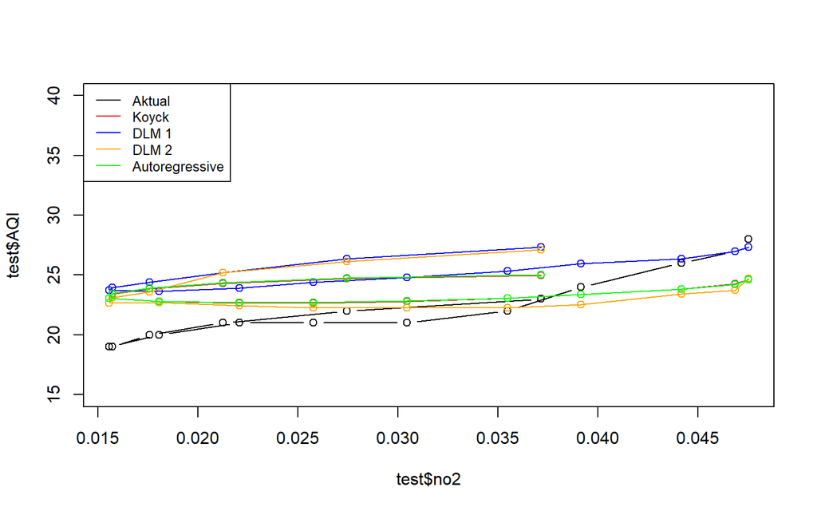

```r
par(mfrow=c(1,1))  # atur layout grafik tunggal

# plot data aktual
plot(test$no2, test$AQI, type="b", col="black", ylim=c(15,40))

# tambahkan garis ramalan dari masing-masing model
points(test$no2, fore.koyck$forecasts, col="red");   lines(test$no2, fore.koyck$forecasts, col="red")
points(test$no2, fore.dlm$forecasts, col="blue");    lines(test$no2, fore.dlm$forecasts, col="blue")
points(test$no2, fore.dlm2$forecasts, col="orange"); lines(test$no2, fore.dlm2$forecasts, col="orange")
points(test$no2, fore.ardl$forecasts, col="green");  lines(test$no2, fore.ardl$forecasts, col="green")

# legenda model
legend("topleft",
       c("Aktual", "Koyck","DLM 1","DLM 2", "Autoregressive"),
       lty=1, col=c("black","red","blue","orange","green"), cex=0.8)
```